# chapter5

Nita Mettinen

2023-12-05

# 5: Dimensionality reduction techniques

```r
#used libraries
library(dplyr)
library(readr)
library(corrplot)
library(tibble)
library(GGally)
library(ggplot2)
library(FactoMineR)
#install.packages("cowplot") done only at first time
library(cowplot)
library(tidyr)
```

## 1. Countries to rownames and graphical overview of the data

```r
#read data
human = read_csv("data/human.csv")

#set countries to rownames and remove Country column
human <- column_to_rownames(human, "Country")

#numerical summaries of the data:
summary(human)
```

```
##     Edu2.FM          Labo.FM          Edu.Exp         Life.Exp
##  Min.   :0.1717   Min.   :0.1857   Min.   : 5.40   Min.   :49.00
##  1st Qu.:0.7264   1st Qu.:0.5984   1st Qu.:11.25   1st Qu.:66.30
##  Median :0.9375   Median :0.7535   Median :13.50   Median :74.20
##  Mean   :0.8529   Mean   :0.7074   Mean   :13.18   Mean   :71.65
##  3rd Qu.:0.9968   3rd Qu.:0.8535   3rd Qu.:15.20   3rd Qu.:77.25
##  Max.   :1.4967   Max.   :1.0380   Max.   :20.20   Max.   :83.50
##       GNI            Mat.Mor         Ado.Birth         Parli.F
##  Min.   :   581   Min.   :   1.0   Min.   :  0.60   Min.   : 0.00
##  1st Qu.:  4198   1st Qu.:  11.5   1st Qu.: 12.65   1st Qu.:12.40
##  Median : 12040   Median :  49.0   Median : 33.60   Median :19.30
##  Mean   : 17628   Mean   : 149.1   Mean   : 47.16   Mean   :20.91
##  3rd Qu.: 24512   3rd Qu.: 190.0   3rd Qu.: 71.95   3rd Qu.:27.95
##  Max.   :123124   Max.   :1100.0   Max.   :204.80   Max.   :57.50
```

```r
#variances
apply(as.matrix(human), 2, var)
```

```
##      Edu2.FM      Labo.FM      Edu.Exp     Life.Exp          GNI      Mat.Mor
## 5.838970e-02 3.951293e-02 8.067024e+00 6.942328e+01 3.438745e+08 4.485483e+04
##    Ado.Birth      Parli.F
## 1.690201e+03 1.319683e+02
```

```r
#standard deviations
apply(as.matrix(human), 2, sd)
```

```
##      Edu2.FM      Labo.FM      Edu.Exp     Life.Exp          GNI      Mat.Mor
## 2.416396e-01 1.987786e-01 2.840251e+00 8.332064e+00 1.854385e+04 2.117896e+02
##    Ado.Birth      Parli.F
## 4.111205e+01 1.148775e+01
```

Interpretation of variable summaries: Summaries show that all variables include numeric data but variables have very different ranges of values and also different means. Variances and standard deviations supply the information seen in summaries, and also those values seem to differ a lot between variables.

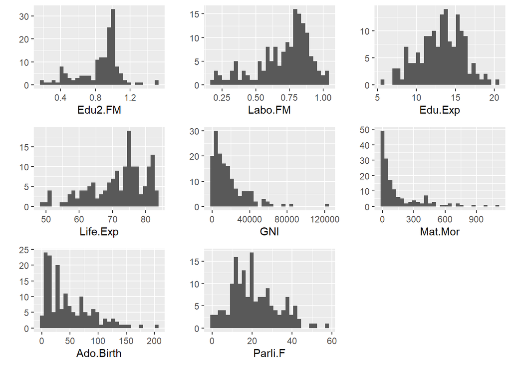

```r
#Graphical overview using histograms and scatterplots and correlation plots

#histograms to define the distributions of variables

list <-lapply(1:ncol(human),
function(col) ggplot2::qplot(human[[col]],
geom = "histogram",
xlab = colnames(human)[col]))
cowplot::plot_grid(plotlist = list)
```

Interpretation of histograms: Edu2.FM, Labo.FM, Edu.Exp and PArli.F have distributions that somewhat resemble normal distribution, which seems to be, however, little bit skewed in Edu2.FM, Labo.FM and Parli.F. Distributions of Life.Exp, GNI, Mat.Mor and Ado.Birth seem to be clearly skewed.

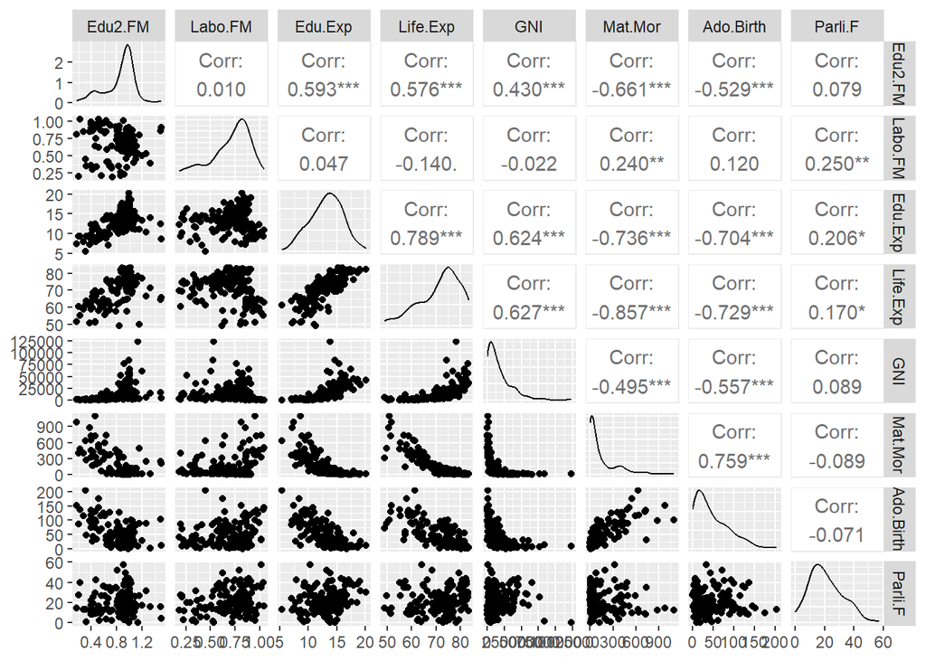

```r
#Relationships of variables:
#Pairwise scatterplots with correlation values and significance of the correlation, supplemented with another correlation plot to visually represent the pariwise correlation strengths

#scatterplot and correlation values and statistical significances
ggpairs(human, progress = F)
```

```r
#correlation matrix calculation and visualization
cor(human)
```

```
##                Edu2.FM      Labo.FM     Edu.Exp   Life.Exp         GNI
## Edu2.FM    1.000000000  0.009564039  0.59325156  0.5760299  0.43030485
## Labo.FM    0.009564039  1.000000000  0.04732183 -0.1400125 -0.02173971
## Edu.Exp    0.593251562  0.047321827  1.00000000  0.7894392  0.62433940
## Life.Exp   0.576029853 -0.140012504  0.78943917  1.0000000  0.62666411
## GNI        0.430304846 -0.021739705  0.62433940  0.6266641  1.00000000
## Mat.Mor   -0.660931770  0.240461075 -0.73570257 -0.8571684 -0.49516234
## Ado.Birth -0.529418415  0.120158862 -0.70356489 -0.7291774 -0.55656208
## Parli.F    0.078635285  0.250232608  0.20608156  0.1700863  0.08920818
##              Mat.Mor  Ado.Birth     Parli.F
## Edu2.FM   -0.6609318 -0.5294184  0.07863528
## Labo.FM    0.2404611  0.1201589  0.25023261
## Edu.Exp   -0.7357026 -0.7035649  0.20608156
## Life.Exp  -0.8571684 -0.7291774  0.17008631
## GNI       -0.4951623 -0.5565621  0.08920818
## Mat.Mor    1.0000000  0.7586615 -0.08944000
## Ado.Birth  0.7586615  1.0000000 -0.07087810
## Parli.F   -0.0894400 -0.0708781  1.00000000
```

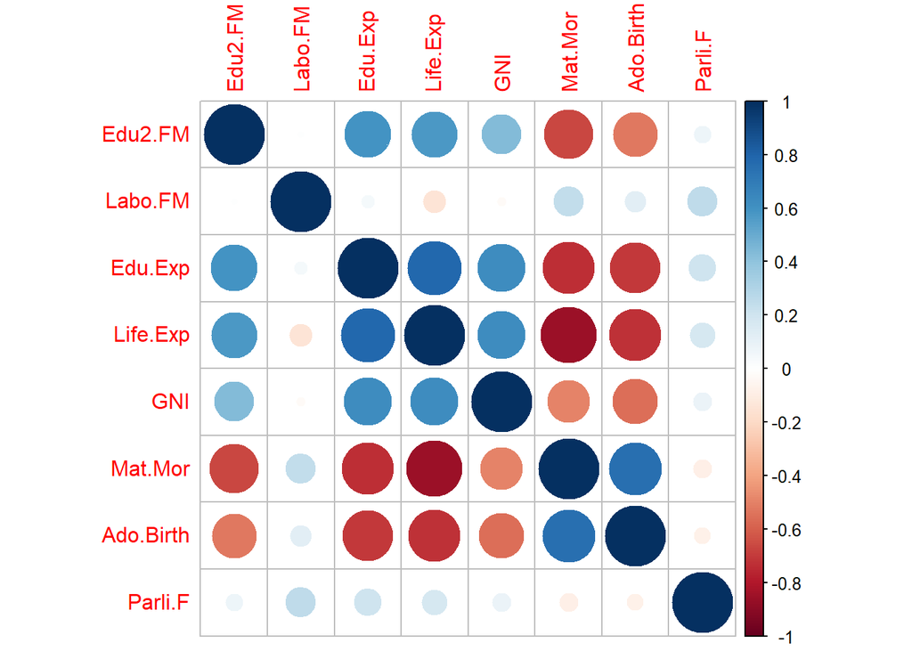

```r
cor(human) %>% corrplot()
```

Interpretation of variable relationship results: From the ggpairs figure visualizing scatterplots, density plots and representing correlation values, I can see that most of the variables correlate statistically significantly and many of them correlate quite strongly (I mean high correlation, values approaching -1 or 1). Some of the scatterplots indicate also clear correlation, for example, scatterplots of Edu.Exp and Life.Exp or Mat.Mor and Life.Exp, but from many of the figures (at least when viewing images at this size) I would not guessed that there is significant correlation between variables, for example, Ado.Birth and GNI. When looking at the correlation matrix created using corrplot, I notice that two variables: Parli.F and Labo.FM do not correlate much with the other variables that, in turn, appear to be systematically correlated with each other.

## 2. PCA with non-standardized human-dataset

```r
# principal component analysis
pca_human <- prcomp(human)

#summary of the PCA
s <- summary(pca_human)

# rounded percentanges of variance captured by each PC
pca_pr <- round(1*s$importance[2, ], digits = 5)

#print the variability captured by each principal component
pca_pr
```

```
##    PC1    PC2    PC3    PC4    PC5    PC6    PC7    PC8
## 0.9999 0.0001 0.0000 0.0000 0.0000 0.0000 0.0000 0.0000
```

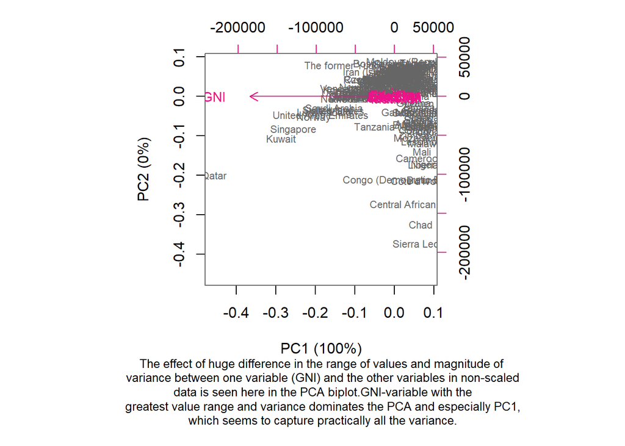

```r
# percentages of variance
pca_pr = round(pca_pr*100, 1)

# stroring variance percentages to pc_lab to be able to be used as axis labels
pc_lab = paste0(names(pca_pr), " (", pca_pr, "%)")

# draw a biplot
#biplot(pca_human, cex = c(0.8, 1), col = c("grey40", "deeppink2"), xlab = pc_lab[1], ylab = pc_lab[2])

#Plot with short description of phenomenom in caption
text1="The effect of huge difference in the range of values and magnitude of\n variance between one variable (GNI) and the other variables in non-scaled\n data is seen here in the PCA biplot.GNI-variable with the\n greatest value range and variance dominates the PCA and especially PC1,\n which seems to capture practically all the variance."
par(mar = c(9, 4, 3, 3))
    biplot(pca_human, cex = c(0.7, 0.9), col = c("grey40", "deeppink2"), xlab = pc_lab[1], ylab = pc_lab[2])
    mtext(text1, side = 1, line = 7, cex = 0.8, adj = 0.5)
```

## 3. PCA with standardized data and interpretation of PCA results with and without standardized data

```r
#standardizing the data with scale-function
sc_human = scale(human)

#summary and variances of scaled data, for comparison
summary(sc_human)
```

```
##     Edu2.FM           Labo.FM           Edu.Exp           Life.Exp
##  Min.   :-2.8189   Min.   :-2.6247   Min.   :-2.7378   Min.   :-2.7188
##  1st Qu.:-0.5233   1st Qu.:-0.5484   1st Qu.:-0.6782   1st Qu.:-0.6425
##  Median : 0.3503   Median : 0.2316   Median : 0.1140   Median : 0.3056
##  Mean   : 0.0000   Mean   : 0.0000   Mean   : 0.0000   Mean   : 0.0000
##  3rd Qu.: 0.5958   3rd Qu.: 0.7350   3rd Qu.: 0.7126   3rd Qu.: 0.6717
##  Max.   : 2.6646   Max.   : 1.6632   Max.   : 2.4730   Max.   : 1.4218
##       GNI             Mat.Mor          Ado.Birth          Parli.F
##  Min.   :-0.9193   Min.   :-0.6992   Min.   :-1.1325   Min.   :-1.8203
##  1st Qu.:-0.7243   1st Qu.:-0.6496   1st Qu.:-0.8394   1st Qu.:-0.7409
##  Median :-0.3013   Median :-0.4726   Median :-0.3298   Median :-0.1403
##  Mean   : 0.0000   Mean   : 0.0000   Mean   : 0.0000   Mean   : 0.0000
##  3rd Qu.: 0.3712   3rd Qu.: 0.1932   3rd Qu.: 0.6030   3rd Qu.: 0.6127
##  Max.   : 5.6890   Max.   : 4.4899   Max.   : 3.8344   Max.   : 3.1850
```

```r
#variances
apply(as.matrix(sc_human), 2, var)
```

```
##   Edu2.FM   Labo.FM   Edu.Exp  Life.Exp       GNI   Mat.Mor Ado.Birth   Parli.F
##         1         1         1         1         1         1         1         1
```

```r
# principal component analysis
sc_pca_human <- prcomp(sc_human)

#summary of the PCA
s_sc <- summary(sc_pca_human)
s_sc
```

```
## Importance of components:
##                           PC1    PC2     PC3     PC4     PC5     PC6     PC7
## Standard deviation     2.0708 1.1397 0.87505 0.77886 0.66196 0.53631 0.45900
## Proportion of Variance 0.5361 0.1624 0.09571 0.07583 0.05477 0.03595 0.02634
## Cumulative Proportion  0.5361 0.6984 0.79413 0.86996 0.92473 0.96069 0.98702
##                            PC8
## Standard deviation     0.32224
## Proportion of Variance 0.01298
## Cumulative Proportion  1.00000
```

```r
# rounded percentanges of variance captured by each PC
sc_pca_pr <- round(1*s_sc$importance[2, ], digits = 5)

#print the variability captured by each principal component
sc_pca_pr
```

```
##     PC1     PC2     PC3     PC4     PC5     PC6     PC7     PC8
## 0.53605 0.16237 0.09571 0.07583 0.05477 0.03595 0.02634 0.01298
```

```r
# percentages of variance
sc_pca_pr = round(sc_pca_pr*100, 1)
sc_pca_pr
```

```
##  PC1  PC2  PC3  PC4  PC5  PC6  PC7  PC8
## 53.6 16.2  9.6  7.6  5.5  3.6  2.6  1.3
```

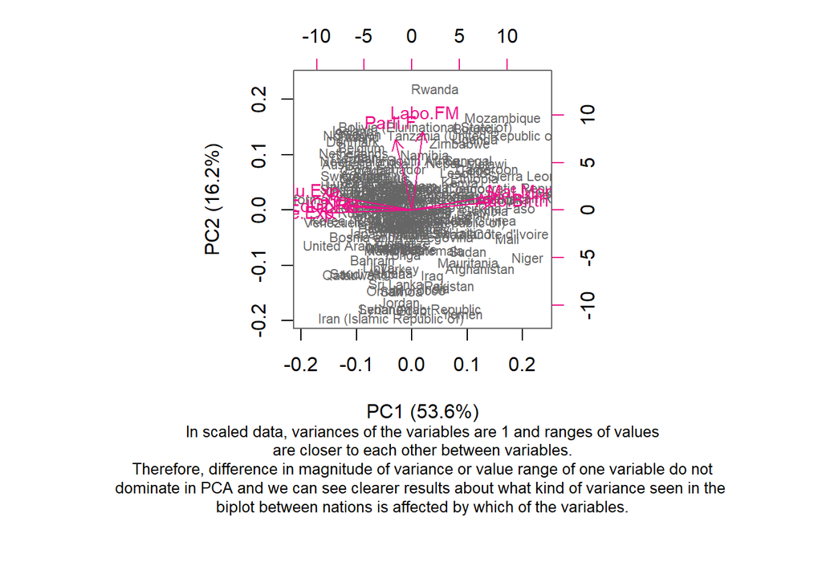

```r
# stroring variance percentages to pc_lab to be able to be used as axis labels
sc_pc_lab = paste0(names(sc_pca_pr), " (", sc_pca_pr, "%)")

# draw a biplot
#biplot(sc_pca_human, cex = c(0.8, 1), col = c("grey40", "deeppink2"), xlab = sc_pc_lab[1], ylab = sc_pc_lab[2])

#Plot with short description of phenomenom in caption
text2="In scaled data, variances of the variables are 1 and ranges of values\n are closer to each other between variables. \n Therefore, difference in magnitude of variance or value range of one variable do not \ndominate in PCA and we can see clearer results about what kind of variance seen in the \nbiplot between nations is affected by which of the variables."
par(mar = c(11, 4, 3, 3))
    biplot(sc_pca_human, cex = c(0.7, 0.9), col = c("grey40", "deeppink2"), xlab = sc_pc_lab[1], ylab = sc_pc_lab[2])
    mtext(text2, side = 1, line = 7, cex = 0.8, adj = 0.5)
```

Interpretation of PCA results: In the biplots, we can see both the countries and variables, and the direction of variance of the variables in relation to the greatest two directions of variation in the data, defined by PC1 and PC2.

Original, not standardized data: Practically all of the variability (0.9999… ~ 1.0 ~ 100%) seems to be captured by the first principal component (PC1). There is only one arrow that stands out from others (I guess the others are there in the pink mess) and it points to the direction of the variable GNI, and, at the same time, it is quite parallel with the PC1 axis’ direction. Therefore, the variable that seems to dominate the principal component analysis and the PC1, is GNI that has clearly the greatest range in values as well as the greatest variance, when the data is not scaled. This kind of phenomenon exists in PCA because in the original data, variables are mainly different type of measures and the range and variance (and mean) of the numerical values between many of the variables differ a lot. For example, the values of Edu2.FM vary between ~0.17 and ~1.50, while the value range of GNI is 581-123124. Variances of the variables also differ in magnitude: GNI has variance many times greater than the variances of other variables. Variance of GNI was ~3.4*10^8, and the second greatest variance that belonged to Mat.Mor was ~4.5*10^4. Even the Mat.Mor variance is many times smaller than the variance of GNI, and rest of the variances are even much smaller.

## 4. (personal) Interpretations of PC1 and PC2

I could say that the PC1 includes variables that define the level of basic conditions for survival, well-being and development of the nation, so PC1 could describe the level of basic conditions for well-being and development in the nation. I think the observations that many European countries and Japan, for example, are located on the left side of center of the biplot, same side where the arrows of education/knowledge, financial and healthy life situation point, support the interpretation. In these countries, people use to get basic education, live to old age, and do well financially on average, compared to the situation in countries seen on the other side of the plot. There we can see, for example, some African or Middle East countries that may have different situation for these variables, as well as for the reproductive health related variables.

The interpretation of the PC2 is more challenging in my opinion. The two variables that explain the variation in that direction present how evenly different genders are represented in working life and government decision-making. I could summarise this like “how equal are the possibilities of genders to participate in society and influence the functioning and development of the society”. However, I can’t say if or how the countries observed in the highest positions of the biplot, for example, tehere are European countries but there are also some African countries, support this theory. I think, though, that my knowledge in geography and social sciences may not be good enough to analyse this properly.

## 5. Tea data and MCA

### Structure and dimensions and overview of the tea data

```r
#read data
tea <- read.csv("https://raw.githubusercontent.com/KimmoVehkalahti/Helsinki-Open-Data-Science/master/datasets/tea.csv", stringsAsFactors = TRUE)

#structure, dimensions and contents
str(tea)
```

```
## 'data.frame':    300 obs. of  36 variables:
##  $ breakfast       : Factor w/ 2 levels "breakfast","Not.breakfast": 1 1 2 2 1 2 1 2 1 1 ...
##  $ tea.time        : Factor w/ 2 levels "Not.tea time",..: 1 1 2 1 1 1 2 2 2 1 ...
##  $ evening         : Factor w/ 2 levels "evening","Not.evening": 2 2 1 2 1 2 2 1 2 1 ...
##  $ lunch           : Factor w/ 2 levels "lunch","Not.lunch": 2 2 2 2 2 2 2 2 2 2 ...
##  $ dinner          : Factor w/ 2 levels "dinner","Not.dinner": 2 2 1 1 2 1 2 2 2 2 ...
##  $ always          : Factor w/ 2 levels "always","Not.always": 2 2 2 2 1 2 2 2 2 2 ...
##  $ home            : Factor w/ 2 levels "home","Not.home": 1 1 1 1 1 1 1 1 1 1 ...
##  $ work            : Factor w/ 2 levels "Not.work","work": 1 1 2 1 1 1 1 1 1 1 ...
##  $ tearoom         : Factor w/ 2 levels "Not.tearoom",..: 1 1 1 1 1 1 1 1 1 2 ...
##  $ friends         : Factor w/ 2 levels "friends","Not.friends": 2 2 1 2 2 2 1 2 2 2 ...
##  $ resto           : Factor w/ 2 levels "Not.resto","resto": 1 1 2 1 1 1 1 1 1 1 ...
##  $ pub             : Factor w/ 2 levels "Not.pub","pub": 1 1 1 1 1 1 1 1 1 1 ...
##  $ Tea             : Factor w/ 3 levels "black","Earl Grey",..: 1 1 2 2 2 2 2 1 2 1 ...
##  $ How             : Factor w/ 4 levels "alone","lemon",..: 1 3 1 1 1 1 1 3 3 1 ...
```

[output cut: 22 more lines]

```r
dim(tea)
```

```
## [1] 300  36
```

```r
#View(tea)
#I will show here a part of the contents with head-function
head(tea)
```

```
##       breakfast     tea.time     evening     lunch     dinner     always home
## 1     breakfast Not.tea time Not.evening Not.lunch Not.dinner Not.always home
## 2     breakfast Not.tea time Not.evening Not.lunch Not.dinner Not.always home
## 3 Not.breakfast     tea time     evening Not.lunch     dinner Not.always home
## 4 Not.breakfast Not.tea time Not.evening Not.lunch     dinner Not.always home
## 5     breakfast Not.tea time     evening Not.lunch Not.dinner     always home
## 6 Not.breakfast Not.tea time Not.evening Not.lunch     dinner Not.always home
##       work     tearoom     friends     resto     pub       Tea   How    sugar
## 1 Not.work Not.tearoom Not.friends Not.resto Not.pub     black alone    sugar
## 2 Not.work Not.tearoom Not.friends Not.resto Not.pub     black  milk No.sugar
## 3     work Not.tearoom     friends     resto Not.pub Earl Grey alone No.sugar
## 4 Not.work Not.tearoom Not.friends Not.resto Not.pub Earl Grey alone    sugar
## 5 Not.work Not.tearoom Not.friends Not.resto Not.pub Earl Grey alone No.sugar
## 6 Not.work Not.tearoom Not.friends Not.resto Not.pub Earl Grey alone No.sugar
##       how       where           price age sex          SPC         Sport age_Q
```

[output cut: 27 more lines]

### Visualizing the tea-data variables with barplots

```r
#data is categorical/factor like, so I use barplot to visualize the variables
length(colnames(tea))#let's divide by four to see something from each barplot
```

```
## [1] 36
```

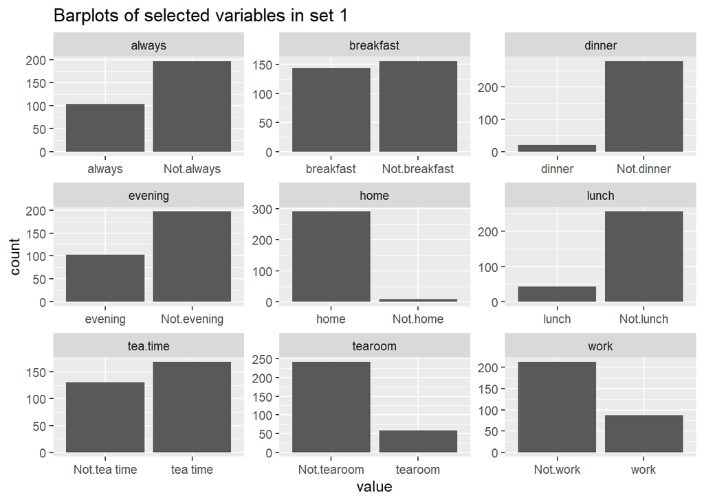

```r
chosen_var1 = colnames(tea)[1:9]
chosen_var2 = colnames(tea)[10:18]
chosen_var3 = colnames(tea)[19:27]
chosen_var4 = colnames(tea)[28:36]

#Barplots to see the overall distribution of values in variables
#set 1
gather(tea[,chosen_var1]) %>% ggplot(aes(value)) + geom_bar() + ggtitle("Barplots of selected variables in set 1") + facet_wrap("key", scales = "free")
```

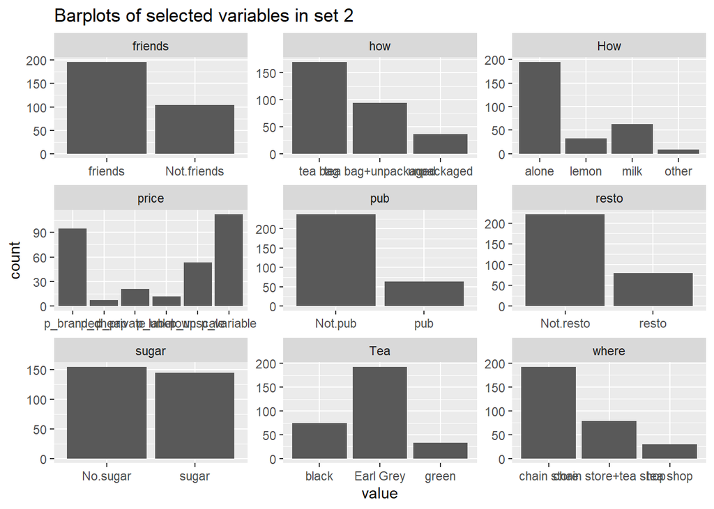

```r
#set2
gather(tea[,chosen_var2]) %>% ggplot(aes(value)) + geom_bar() + ggtitle("Barplots of selected variables in set 2") + facet_wrap("key", scales = "free")
```

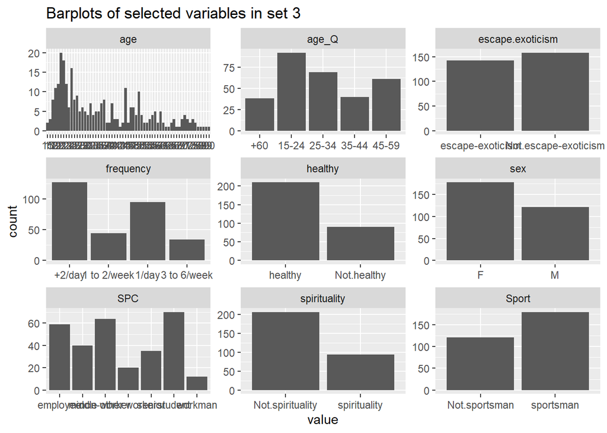

```r
#set3
gather(tea[,chosen_var3]) %>% ggplot(aes(value)) + geom_bar() + ggtitle("Barplots of selected variables in set 3") + facet_wrap("key", scales = "free")
```

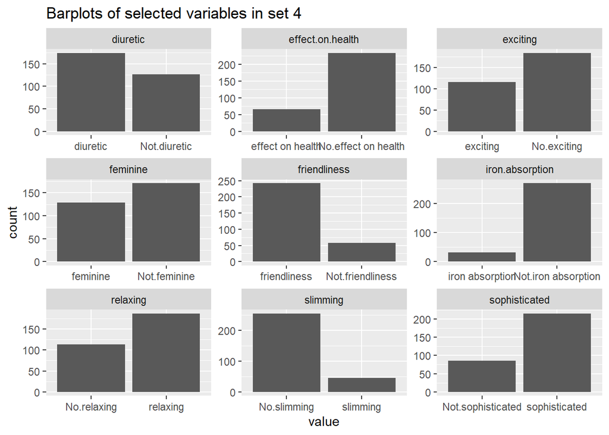

```r
#set4
gather(tea[,chosen_var4]) %>% ggplot(aes(value)) + geom_bar() + ggtitle("Barplots of selected variables in set 4") + facet_wrap("key", scales = "free")
```

### MCA analysis and biplot

I will include only couple of columns of the tea data used earlier in the exercise 5 to (hopefully) keep the result of the analysis as well as the plot simpler

```r
# limit data to only couple of variables
keep_columns <- c("Tea", "How", "how", "sugar", "where", "lunch")

# select the 'keep_columns' to create a new dataset
tea_time <- tea[,keep_columns]

# multiple correspondence analysis = MCA
mca <- MCA(tea_time, graph = FALSE)

# summary of the model
summary(mca)
```

```
##
## Call:
## MCA(X = tea_time, graph = FALSE)
##
##
## Eigenvalues
##                        Dim.1   Dim.2   Dim.3   Dim.4   Dim.5   Dim.6   Dim.7
## Variance               0.279   0.261   0.219   0.189   0.177   0.156   0.144
## % of var.             15.238  14.232  11.964  10.333   9.667   8.519   7.841
## Cumulative % of var.  15.238  29.471  41.435  51.768  61.434  69.953  77.794
##                        Dim.8   Dim.9  Dim.10  Dim.11
## Variance               0.141   0.117   0.087   0.062
## % of var.              7.705   6.392   4.724   3.385
## Cumulative % of var.  85.500  91.891  96.615 100.000
##
## Individuals (the 10 first)
##                       Dim.1    ctr   cos2    Dim.2    ctr   cos2    Dim.3
## 1                  | -0.298  0.106  0.086 | -0.328  0.137  0.105 | -0.327
## 2                  | -0.237  0.067  0.036 | -0.136  0.024  0.012 | -0.695
## 3                  | -0.369  0.162  0.231 | -0.300  0.115  0.153 | -0.202
## 4                  | -0.530  0.335  0.460 | -0.318  0.129  0.166 |  0.211
## 5                  | -0.369  0.162  0.231 | -0.300  0.115  0.153 | -0.202
## 6                  | -0.369  0.162  0.231 | -0.300  0.115  0.153 | -0.202
## 7                  | -0.369  0.162  0.231 | -0.300  0.115  0.153 | -0.202
## 8                  | -0.237  0.067  0.036 | -0.136  0.024  0.012 | -0.695
## 9                  |  0.143  0.024  0.012 |  0.871  0.969  0.435 | -0.067
## 10                 |  0.476  0.271  0.140 |  0.687  0.604  0.291 | -0.650
##                       ctr   cos2
## 1                   0.163  0.104 |
## 2                   0.735  0.314 |
## 3                   0.062  0.069 |
## 4                   0.068  0.073 |
## 5                   0.062  0.069 |
## 6                   0.062  0.069 |
## 7                   0.062  0.069 |
## 8                   0.735  0.314 |
## 9                   0.007  0.003 |
## 10                  0.643  0.261 |
##
## Categories (the 10 first)
```

[output cut: 16 more lines]

```
## lemon                3.226 |   1.329  14.771   0.218   8.081 |
## milk                 2.422 |   0.013   0.003   0.000   0.116 |
## other                5.534 |  -2.524  14.526   0.197  -7.676 |
## tea bag             -6.941 |  -0.065   0.183   0.006  -1.287 |
## tea bag+unpackaged  11.956 |   0.019   0.009   0.000   0.226 |
## unpackaged          -6.482 |   0.257   0.602   0.009   1.640 |
##
## Categorical variables (eta2)
##                      Dim.1 Dim.2 Dim.3
## Tea                | 0.126 0.108 0.410 |
## How                | 0.076 0.190 0.394 |
## how                | 0.708 0.522 0.010 |
## sugar              | 0.065 0.001 0.336 |
## where              | 0.702 0.681 0.055 |
## lunch              | 0.000 0.064 0.111 |
```

Interpretation of MCA results: As denoted in the Exercise 5 introduction to MCA: “(MCA) is a method to analyze qualitative data and it is an extension of Correspondence analysis (CA). MCA can be used to detect patterns or structure in the data as well as in dimension reduction.” and this was, I guess, related to the source [Multiple Correspondence Analysis](https://en.wikipedia.org/wiki/Multiple_correspondence_analysis) (visited 5.12.2023). According to this source and summary of it from the Exercise 5, MCA is quite equal to PCA, since as a result, data points are represented in low-dimensional Euclidean space (dimensionality reduction and Euclidean distance, as in the PCA), but the methods to get there differ. Instead of covariance matrix, there is table of pairwise cross-tabulations called Burt table. Also as a result, there are ‘dimensions’ in the importance order, where importance is related to maximum oppositions between rows and columns, or maximum variance observed, as in the PCA. So, the most important dimension captures most of the variance in the data, the second dimension the second highest proportion of the variance and so on.

Summary of the MCA maybe the result to interpret at this point, as it represents the dimension values for (the first ten) individuals and variable categories as well as the total variance and proportion of variance explained by the dimensions (Dim.1-Dim.11), which are the results from MCA. The most important dimension, Dim.1, seems to capture ~15.2% of the total variance, but the second most important dimension, Dim.2, captures almost equal proportion of the total variance: 14.2%. The proportion of explained variance seem to stay more equal between dimensions with reducing importance than I expected based on PCA, where the proportion of explained variance typically reduces faster with the importance. The values related to individuals or categories of variables maybe better to interpret from the visual representation, biplot in this case.

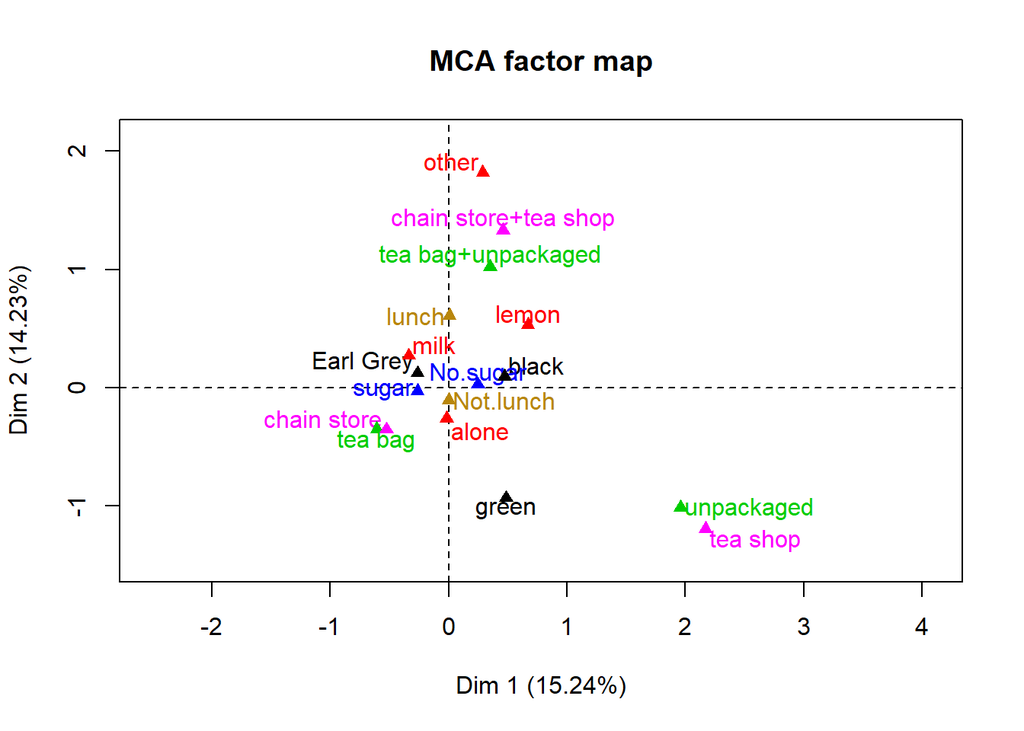

```r
# visualize MCA
#variables (and their categories) only
plot(mca, invisible=c("ind"), graph.type = "classic", habillage = "quali")
```

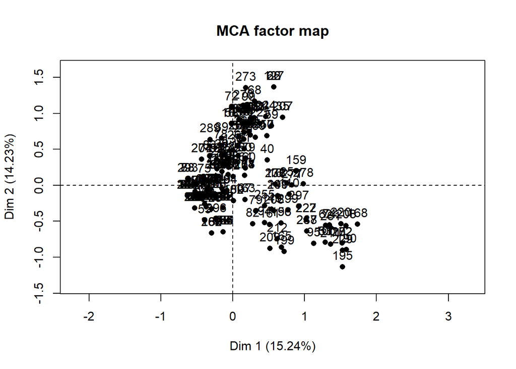

```r
#individuals only
plot(mca, invisible=c("var"), graph.type = "classic")
```

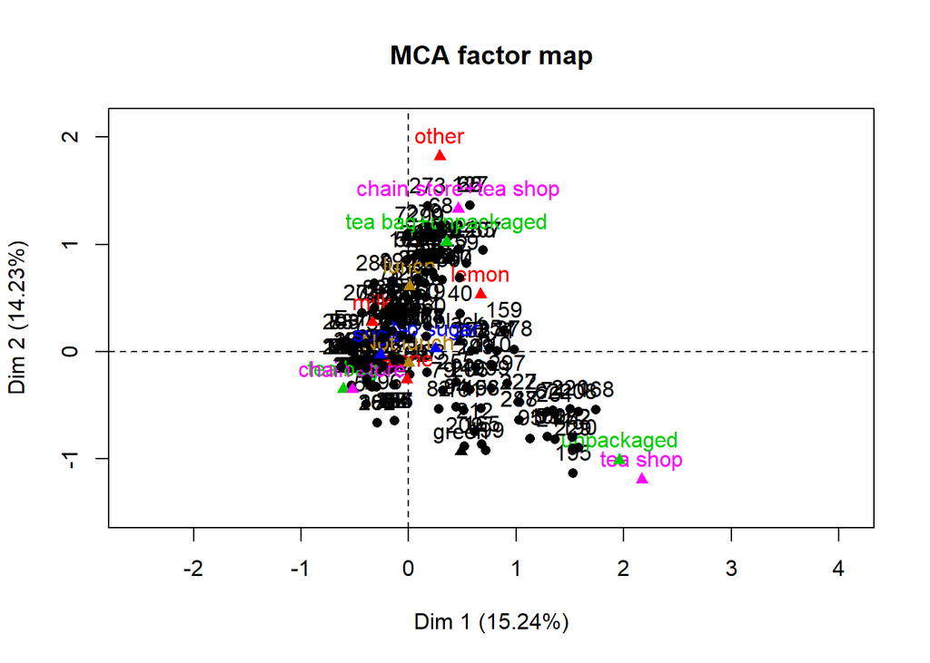

```r
#individuals and variables
plot(mca, invisible=c("none"), graph.type = "classic", habillage = "quali")
```

Interpretation of MCA bioplots: We can observe some potential underlying structures of the data in the MCA biplots. In the first plot, including categories of variables and different variables represented with different colors, we can see how distant are the categories of same variable from each other, or, which of them vary more, and with which categories of other variables some of them seem to group. The next plot containing only individuals follows the pattern outlined by the categories in the first plot. The individuals with more similar preferences with tea are nearer each other in the biplot than those having different preferences. When showing both the variables and the individuals in the same plot (the third biplot), we can see which individuals have more similar preferences with tea and what those preferences would be according to the nearest groups of categories. On the other hand, individuals located far away from each other probably prefer different categories, which also are (probably) located away from the other categories, and these individuals and categories potentially form another group with more similarities within this group than others around.  
For example, I could interpret that the individuals located nearby each other in the lower righ rectangle (delineated by lines) might prefer green tea, bought as unpacked from a tea shop. They have opinions or preferences to other variables too, but they may not be seen as clearly from the biplot. If I take a closer look to one individual, I would observe that individual 195 is located closest to the lower righ corner of the biplot, and according to the data, this individual prefers: green tea, alone, unpackaged, No.sugar, bought from tea shop and Not.lunch (tea?). These categories from each variables seem to be closest to the individual in the biplot, so it seems that the grouping fitted well in this extreme individual point case.